# Machine Downtime Analysis 2

Sridhar Kothalanka

2/21/2020

### Overview

In the below exercise EDA is performed on a dataset to understand the machine downtime patterns. The goal is to look at the charts and find out any hidden patterns in the dataset this should help in asking more questions to the domain expert.This is a cyclic process and will be repeated multiple times before the dataset is finalized and an ML model is created.

## Steps

1. Load the necessary R libraries
2. Load the data
3. Plot the data for Station-1
4. Quick observations
5. Repeat plotting for rest of the machines
6. Average usage of machines for production and maintance modes
7. Summary

### 1. Load the necessary R libraries

```r
library(ggplot2)
library(magrittr)
library(dplyr)
library(tidyr)
library(ggpubr)
```

### 2. Load the data

The raw data sets consists of observations of 6 machines across 3 shifts and its utilization over a period of 1 year. The raw data was processed and features like “day of the week”, “maintFlag”, and “useHrs” was added to get a quick understanding of any machine downtime patterns.

|  | Station_ID | maintFlag | useHrs | WRK_DAY3 |
| --- | --- | --- | --- | --- |
| 1 | Station-1 | 0 | 4 | 2020-02-17 |
| 2 | Station-1 | 1 | 24 | 2020-02-16 |
| 3 | Station-1 | 1 | 24 | 2020-02-15 |
| 4 | Station-1 | 1 | 24 | 2020-02-14 |
| 5 | Station-1 | 0 | 24 | 2020-02-13 |
| 6 | Station-1 | 0 | 24 | 2020-02-12 |

### 3. Plot the data for Station-1

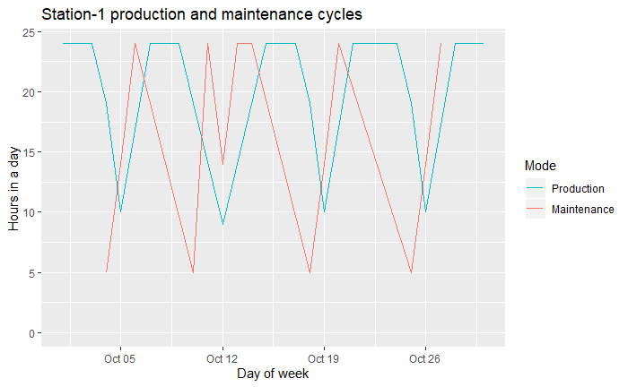

```r
df1 <- read.csv("../data/eda-pm-ds2/Station2-type1-1.csv")
df1$WRK_DAY3 <- as.Date(df1$WRK_DAY2 , format = "%m/%d/%y")
df1 <- df1 %>% select(-c("WRK_DAY2"))
#df1 <- df1 %>% filter(df1$WRK_DAY3 >= as.Date("2020-10-20") && df1$WRK_DAY3 <= as.Date("2020-10-30"))
#df1 <- df1 %>% filter(df1$WRK_DAY3 >= as.Date("2020-10-20"))
df1 <- df1 %>% filter(df1$WRK_DAY3 >= as.Date("2020-10-01") & df1$WRK_DAY3 <= as.Date("2020-10-30"))
ggplot(df1, aes(x=WRK_DAY3,y=useHrs,color=factor(maintFlag))) +
  scale_color_manual("Mode", values = c("0" = "#00BFC4", "1" = "#F8766D"),labels = c("Production", "Maintenance")) +
  geom_line() +
  ylim(0,24) +
  xlab("Day of week") +
  ylab("Hours in a day") +
  ggtitle("Station-1 production and maintenance cycles")
```

### 5. Repeat plotting for all stations

Repeat plotting for all stations to see if the pattern repeats or differs

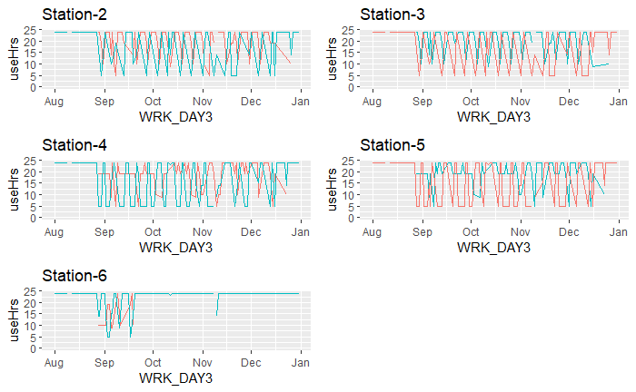

```r
df1 <- read.csv("../data/eda-pm-ds2/Station2-type1-1.csv")
df1$WRK_DAY3 <- as.Date(df1$WRK_DAY2 , format = "%m/%d/%y")
df1 <- df1 %>% select(-c("WRK_DAY2"))
df1 <- df1 %>% filter(df1$WRK_DAY3 >= as.Date("2020-08-01"))
p1 <- ggplot(df1, aes(x=WRK_DAY3,y=useHrs,color=factor(maintFlag))) +
    #scale_color_manual("Mode", values = c("0" = "#00BFC4", "1" = "#F8766D"),labels = c("Production", "Maintenance")) +
    theme(legend.position = "none") +
    geom_line() +
    ylim(0,24) +
    ggtitle("Station-2")


df1 <- read.csv("../data/eda-pm-ds2/Station3-type1-1.csv")
df1$WRK_DAY3 <- as.Date(df1$WRK_DAY2 , format = "%m/%d/%y")
df1 <- df1 %>% select(-c("WRK_DAY2"))
df1 <- df1 %>% filter(df1$WRK_DAY3 >= as.Date("2020-08-01"))
p2 <- ggplot(df1, aes(x=WRK_DAY3,y=useHrs,color=factor(maintFlag))) +
    scale_color_manual("Mode", values = c("0" = "#00BFC4", "1" = "#F8766D"),labels = c("Production", "Maintenance")) +
    theme(legend.position = "none") +
    geom_line() +
    ylim(0,24) +
    ggtitle("Station-3")

df1 <- read.csv("../data/eda-pm-ds2/Station4-type1-1.csv")
df1$WRK_DAY3 <- as.Date(df1$WRK_DAY2 , format = "%m/%d/%y")
df1 <- df1 %>% select(-c("WRK_DAY2"))
df1 <- df1 %>% filter(df1$WRK_DAY3 >= as.Date("2020-08-01"))
p3 <- ggplot(df1, aes(x=WRK_DAY3,y=useHrs,color=factor(maintFlag))) +
    #scale_color_manual("Mode", values = c("0" = "#00BFC4", "1" = "#F8766D"),labels = c("Production", "Maintenance")) +
    theme(legend.position = "none") +
    geom_line() +
    ylim(0,24) +
    ggtitle("Station-4")

df1 <- read.csv("../data/eda-pm-ds2/Station5-type1-1.csv")
df1$WRK_DAY3 <- as.Date(df1$WRK_DAY2 , format = "%m/%d/%y")
df1 <- df1 %>% select(-c("WRK_DAY2"))
df1 <- df1 %>% filter(df1$WRK_DAY3 >= as.Date("2020-08-01"))
p4 <- ggplot(df1, aes(x=WRK_DAY3,y=useHrs,color=factor(maintFlag))) +
    scale_color_manual("Mode", values = c("0" = "#00BFC4", "1" = "#F8766D"),labels = c("Production", "Maintenance")) +
    theme(legend.position = "none") +
    geom_line() +
    ylim(0,24) +
    ggtitle("Station-5")

df1 <- read.csv("../data/eda-pm-ds2/Station6-type1-1.csv")
df1$WRK_DAY3 <- as.Date(df1$WRK_DAY2 , format = "%m/%d/%y")
df1 <- df1 %>% select(-c("WRK_DAY2"))
df1 <- df1 %>% filter(df1$WRK_DAY3 >= as.Date("2020-08-01"))
p5 <- ggplot(df1, aes(x=WRK_DAY3,y=useHrs,color=factor(maintFlag))) +
    #scale_color_manual("Mode", values = c("0" = "#00BFC4", "1" = "#F8766D"),labels = c("Production", "Maintenance")) +
    theme(legend.position = "none") +
    geom_line() +
    ylim(0,24) +
    ggtitle("Station-6")

figure <- ggarrange(p1, p2, p3, p4, p5, ncol = 2, nrow = 3)
figure
```

```r
NA
```

### 6. Average usage of machines for production and maintance modes

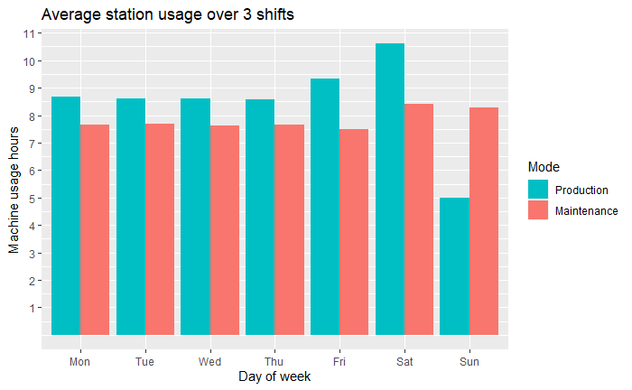

### 7. Summary

1. Every production cycle is followed by a maintenance cycle or vice versa.
2. Need to understand what maintenance is done on the machine, is it something that is mandatory or optional (preventive maintenance).
3. If it is optional, is there any metric to detect that the machine is nearing its real maintenance cycle
4. Inorder to build a model that can perform downtime, more features are needed beyond “utilization”.
5. Additionally when we have the right data the data needs to be labelled so that we can train a model to predict downtime of machines